# R4. LIMA identifiability and z-score threshold sensitivity

This notebook reproduces, from saved result files, every number that the manuscript quotes for

- **Experiment 12, LIMA identifiability and regularization** (Materials and Methods, "LIMA construction and application for root development"; Figure S15A to S15C),
- **Experiment 13, z-score threshold sensitivity** (Figure S15D to S15F).

The scripts are in `../codes/`. The cluster commands are shown but not executed. Each number is followed by an `assert`.

| Claim in the manuscript | Section |
| --- | --- |
| The least-squares solver of the pipeline retains 4 to 32 of the 200 singular directions (median 11) | 1.1 |
| The TF ranking of the minimum-norm and ridge solutions (lambda = 0.01 to 10) correlates at 0.81 to 0.92 with that of the pipeline solution | 1.2 |
| 21% to 36% of the thresholded TF edges are shared with the pipeline solution | 1.2 |
| Changing the number of generated rows (50 to 800) or the latent sampling spread (0.5 to 2 times) changes split-half stability by no more than 0.02 | 1.3 |
| R50 of the TF degree ranking is 328 to 375 under every solver, against a permutation baseline of 741 | 1.4 |
| At a threshold of 3, 0.9 to 1.3% of the possible edges are retained | 2.2 |
| Recall of the gold standard is stable across thresholds, 0.7 to 5.0% for K = 100 to 400 | 2.3 |

```python
import os, json
import numpy as np
import pandas as pd
from IPython.display import Image, display

R = os.path.join('..', 'results')                           # result files of the revision folder
pct = lambda x: round(100 * float(x), 1)                    # accuracy as a percentage with one decimal

# Figures are drawn by codes/exp24_manuscript_figures.py from the result tables in R
import importlib.util
os.environ['GENESYS_RESULTS'] = os.path.abspath(R)
os.environ['GENESYS_FIGURES'] = os.path.abspath(os.path.join(R, 'figures'))
_spec = importlib.util.spec_from_file_location('figures', os.path.join('..', 'codes', 'exp24_manuscript_figures.py'))
figures = importlib.util.module_from_spec(_spec)
_spec.loader.exec_module(figures)

def load_json(*parts):
    with open(os.path.join(R, *parts)) as fh:
        return json.load(fh)
```

## 1. Experiment 12: LIMA identifiability and regularization (Figure S15A to S15C)

A LIMA estimates a 17,513 by 17,513 matrix from about 200 rows, so the least-squares problem is underdetermined. `exp16_lima_identifiability.py` tests how much the TF ranking depends on the solver. It uses the published model and the transition t1 to t3, and recomputes the LIMA

- with three kinds of **solver** (200 generated rows per state): the call of the LIMA pipeline (`torch.linalg.lstsq` on CPU tensors, as in notebook 12, which discards the singular directions below its default rank cutoff), the **minimum-norm** least-squares solution with every singular direction kept, and **ridge regression** with lambda = 0.01, 0.1, 1 and 10,
- with **50, 200 and 800 generated rows** per state (pipeline solver),
- with the **latent sampling spread** of the TD-VAE scaled by 0.5, 1 and 2 (pipeline solver).

The generated states follow notebook 12 (test split, batches of 2,000 trajectories, `generate_next` at the slots of the transition), with 11 batches per condition as in the notebook. The minimum-norm and ridge solutions are obtained through the singular value decomposition. The replicate matrices are averaged, the averaged matrix is thresholded at |z| > 3 (z-score over all entries of the matrix), and the TFs are ranked by the degree centrality of the TF network of notebook 12 (TF-by-TF subnetwork, TFs with at least one edge in each direction, NetworkX degree centrality, min-max normalized per cell type and summed over the ten cell types). Reported for each condition: the Spearman correlation of this TF ranking with that of the pipeline solution, the fraction of thresholded TF edges shared with the pipeline solution (Jaccard index, mean over the ten cell types), the split-half stability (Spearman correlation between the TF rankings obtained from the first five and the last six replicates), and the R50 of the ranking among the 1,495 TFs (ties broken at random, mean of 200 draws).

```python
# Commands used on the cluster (not executed here): one CPU job per condition, then a merge job
#   for i in 0 1 2 3 4 5 6 7 8 9; do
#     sbatch --job-name=e16c_$i --time=06:00:00 experiments/slurm/run_cpu.sh experiments/exp16_lima_identifiability.py --only $i --device cpu
#   done
#   sbatch --job-name=e16c_merge --dependency=afterok:<job ids> experiments/slurm/run_cpu.sh experiments/exp16_lima_identifiability.py --merge
```

### 1.1 Singular directions retained by the pipeline solver

```python
I = 'exp16_identifiability'
agree = pd.read_csv(os.path.join(R, I, 'exp16_ranking_agreement.csv')).set_index('label')
cond = pd.read_csv(os.path.join(R, I, 'exp16_conditions.csv')).set_index('label')
ranks = pd.read_csv(os.path.join(R, I, 'exp16_ranks.csv'))

BASE = 'ridge_rows200_eps1.0_lam0'                                   # the pipeline solution
MINNORM = 'minnorm_rows200_eps1.0_lamminnorm'
RIDGE = [f'ridge_rows200_eps1.0_lam{l}' for l in ['0.01', '0.1', '1.0', '10.0']]

rk = ranks[ranks['label'] == BASE]
assert len(rk) == 110 and rk['cell_type'].nunique() == 10            # 11 batches for each of the ten cell types
print('rows per fit:', rk['rows'].min(), 'to', rk['rows'].max())
print('directions retained by torch.linalg.lstsq: min', rk['rank'].min(), ', median', rk['rank'].median(), ', max', rk['rank'].max())
assert (rk['rank'].min(), rk['rank'].median(), rk['rank'].max()) == (4, 11, 32)
# the minimum-norm and ridge solutions keep every direction
full = ranks[ranks['label'].isin([MINNORM] + RIDGE)]
assert (full['rank'] == full['rows']).all()
```

```
rows per fit: 183 to 200
directions retained by torch.linalg.lstsq: min 4 , median 11.0 , max 32
```

On CPU tensors `torch.linalg.lstsq` treats the directions below its default cutoff as zero, so the solution of the pipeline uses only the dominant directions of variation among the sampled cells. This acts as an implicit regularization.

### 1.2 Agreement of the minimum-norm and ridge solutions with the pipeline solution (Figure S15A)

```python
alt = [MINNORM] + RIDGE
tab = agree.loc[alt, ['spearman_vs_lstsq_baseline', 'edge_jaccard_vs_baseline_mean']]
tab.columns = ['Spearman vs pipeline', 'shared thresholded TF edges']
print(tab.round(3).to_string())

rho = tab['Spearman vs pipeline']
assert [round(v, 3) for v in rho] == [0.814, 0.823, 0.843, 0.890, 0.916]
assert (round(rho.min(), 2), round(rho.max(), 2)) == (0.81, 0.92)
assert rho[RIDGE].is_monotonic_increasing                            # agreement increases with the penalty
jac = tab['shared thresholded TF edges']
assert (round(100 * jac.min()), round(100 * jac.max())) == (21, 36)

half = cond.loc[BASE, 'splithalf_spearman_tf']
print('\nsplit-half stability of the pipeline solution:', round(half, 3))
assert round(half, 2) == 0.94
```

```
                                   Spearman vs pipeline  shared thresholded TF edges
label
minnorm_rows200_eps1.0_lamminnorm                 0.814                        0.210
ridge_rows200_eps1.0_lam0.01                      0.823                        0.223
ridge_rows200_eps1.0_lam0.1                       0.843                        0.244
ridge_rows200_eps1.0_lam1.0                       0.890                        0.293
ridge_rows200_eps1.0_lam10.0                      0.916                        0.363

split-half stability of the pipeline solution: 0.943
```

The TF ranking of the minimum-norm solution and of the ridge solutions over a thousandfold range of the penalty correlates at 0.81 to 0.92 with the ranking of the pipeline solution. The agreement is lowest for the solutions that keep the weak directions and increases with the penalty. Two independent halves of the pipeline replicates correlate at 0.94. The individual edges are less stable than the ranking: 21% to 36% of the thresholded TF edges are shared with the pipeline solution.

### 1.3 Split-half stability across sample sizes and sampling spreads (Figure S15B)

```python
base = cond.loc[BASE]
others = ['rows_rows50_eps1.0_lam0', 'rows_rows800_eps1.0_lam0', 'spread_rows200_eps0.5_lam0', 'spread_rows200_eps2.0_lam0']
stab = cond.loc[[BASE] + others, ['n_rows', 'eps_scale', 'splithalf_spearman_tf', 'splithalf_spearman_all']]
print(stab.round(3).to_string())

assert [round(v, 3) for v in stab['splithalf_spearman_tf']] == [0.943, 0.936, 0.960, 0.950, 0.941]
change = (cond.loc[others, 'splithalf_spearman_tf'] - base['splithalf_spearman_tf']).abs()
print('\nlargest change from the default (200 rows, spread 1):', round(change.max(), 3))
assert round(change.max(), 3) == 0.017 and change.max() <= 0.02
# split-half stability of the minimum-norm and ridge solutions
rs = cond.loc[[MINNORM] + RIDGE, 'splithalf_spearman_tf']
print(rs.round(3).to_string())
assert rs.min() > 0.95
```

```
                            n_rows  eps_scale  splithalf_spearman_tf  splithalf_spearman_all
label
ridge_rows200_eps1.0_lam0      200        1.0                  0.943                   0.969
rows_rows50_eps1.0_lam0         50        1.0                  0.936                   0.961
rows_rows800_eps1.0_lam0       800        1.0                  0.960                   0.980
spread_rows200_eps0.5_lam0     200        0.5                  0.950                   0.968
spread_rows200_eps2.0_lam0     200        2.0                  0.941                   0.969

largest change from the default (200 rows, spread 1): 0.017
label
minnorm_rows200_eps1.0_lamminnorm    0.963
ridge_rows200_eps1.0_lam0.01         0.964
ridge_rows200_eps1.0_lam0.1          0.965
ridge_rows200_eps1.0_lam1.0          0.968
ridge_rows200_eps1.0_lam10.0         0.963
```

### 1.4 R50 of the TF degree ranking in each condition (Figure S15C)

```python
r50 = cond[['condition', 'n_rows', 'eps_scale', 'lambda', 'r50_tf_degree', 'r50_permutation']].copy()
print(r50.round(0).to_string())

perm = cond['r50_permutation'].iloc[0]
assert round(perm) == 741 and cond['r50_permutation'].nunique() == 1
solvers = cond.loc[[BASE, MINNORM] + RIDGE, 'r50_tf_degree'].round().astype(int)
assert list(solvers) == [330, 374, 375, 359, 347, 328]
assert (solvers.min(), solvers.max()) == (328, 375) and solvers.max() < perm      # "R50 of 328 to 375 against 741"

rows_spread = cond.loc[['rows_rows50_eps1.0_lam0', 'rows_rows800_eps1.0_lam0',
                        'spread_rows200_eps0.5_lam0', 'spread_rows200_eps2.0_lam0'], 'r50_tf_degree'].round().astype(int)
assert list(rows_spread) == [330, 349, 356, 318]
assert cond['r50_tf_degree'].max() < 0.52 * perm                     # every condition recovers the gold standard well ahead of chance
```

```
                                  condition  n_rows  eps_scale  lambda  r50_tf_degree  r50_permutation
label
ridge_rows200_eps1.0_lam0             ridge     200        1.0     0.0          330.0            741.0
ridge_rows200_eps1.0_lam0.01          ridge     200        1.0     0.0          375.0            741.0
ridge_rows200_eps1.0_lam0.1           ridge     200        1.0     0.0          359.0            741.0
ridge_rows200_eps1.0_lam1.0           ridge     200        1.0     1.0          347.0            741.0
ridge_rows200_eps1.0_lam10.0          ridge     200        1.0    10.0          328.0            741.0
minnorm_rows200_eps1.0_lamminnorm   minnorm     200        1.0    -1.0          374.0            741.0
rows_rows50_eps1.0_lam0                rows      50        1.0     0.0          330.0            741.0
rows_rows800_eps1.0_lam0               rows     800        1.0     0.0          349.0            741.0
spread_rows200_eps0.5_lam0           spread     200        0.0     0.0          356.0            741.0
spread_rows200_eps2.0_lam0           spread     200        2.0     0.0          318.0            741.0
```

The gold-standard TFs are recovered well ahead of the permutation baseline under every solver, sample size and spread. The R50 falls from 356 to 318 as the latent sampling spread goes from 0.5 to 2 times.

## 2. Experiment 13: z-score threshold sensitivity (Figure S15D to S15F)

The published LIMAs (one 17,513 by 17,513 matrix per cell type and transition) are thresholded again at |z| > 2.0, 2.5, 3.0 and 4.0. The z-score of an entry is taken against the mean and standard deviation of all entries of its matrix, as in notebook 12. `exp5_zscore_sensitivity.py` counts the retained edges, and `exp9_zscore_tf_recovery.py` ranks all 17,513 genes by degree (sum of the absolute weights of the retained in-coming and out-going edges, summed over the ten cell types) and measures the recall of the gold-standard TFs among the top K genes.

```python
# Commands used on the cluster (not executed here):
#   sbatch --job-name=z_exp5 --cpus-per-task=8 experiments/slurm/run_cpu.sh experiments/exp5_zscore_sensitivity.py
#   sbatch --job-name=z_exp9 --cpus-per-task=8 experiments/slurm/run_cpu.sh experiments/exp9_zscore_tf_recovery.py
```

### 2.2 Fraction of edges retained (Figure S15D and S15E)

```python
edges = pd.read_csv(os.path.join(R, 'exp5_zscore_edge_counts.csv'))
frac = (edges.pivot(index='transition', columns='threshold', values='fraction') * 100).round(2)
print(frac.to_string())

at3 = edges[edges['threshold'] == 3.0]['n_edges'] / edges[edges['threshold'] == 3.0]['n_possible'] * 100
print('retained at |z| > 3 (%):', [round(v, 2) for v in at3])
assert (round(at3.min(), 1), round(at3.max(), 1)) == (0.9, 1.3)      # "0.9 to 1.3% of edges are retained"
assert (frac.diff(axis=1).iloc[:, 1:] < 0).all().all()               # retention falls smoothly with the threshold

# The denominator: the ten cell-type matrices of a transition together hold 10 x 17,513^2 entries.
n_possible = int(edges['n_possible'].iloc[0])
print('\npossible edges per transition:', f'{n_possible:,}', '= 10 x 17,513^2 =', f'{10 * 17513**2:,}')
assert n_possible == 10 * 17513 ** 2 and edges['n_possible'].nunique() == 1
```

```
threshold    2.0   2.5   3.0   4.0
transition
t0-t1       2.26  1.65  1.25  0.80
t1-t3       2.25  1.63  1.23  0.78
t3-t5       1.82  1.32  1.01  0.64
t5-t7       1.59  1.17  0.90  0.59
t7-t9       1.49  1.11  0.87  0.57
retained at |z| > 3 (%): [1.25, 1.23, 1.01, 0.9, 0.87]

possible edges per transition: 3,067,051,690 = 10 x 17,513^2 = 3,067,051,690
```

The number of possible edges per transition is 10 x 17,513² = 3.07 x 10⁹, because the count runs over the ten cell-type matrices of a transition. One matrix holds 17,513² = 3.07 x 10⁸ entries.

### 2.3 Recall of the gold standard at each threshold (Figure S15F)

```python
agg = pd.read_csv(os.path.join(R, 'exp9_zscore_tf_recovery_aggregate.csv'))
gold = agg[agg['gold_standard'] == 'Intersection']                   # the 140 TFs shared by MINI-EX and StringDB
assert set(gold['n_gold_total']) == {140} and gold['transition'].nunique() == 5

# mean over the five transitions
recall = (gold.groupby(['threshold', 'K'])['recall'].mean().unstack() * 100).round(1)
print(recall.to_string())

used = recall.loc[[2.0, 2.5, 3.0, 4.0]]                              # the thresholds named in the Methods
assert (used.values.min(), used.values.max()) == (0.7, 5.0)          # "0.7 to 5.0% at K = 100 to 400"
assert (used.max() - used.min()).max() <= 0.8                        # stable across thresholds, within one percentage point
print('\nexpected by chance at K = 100, 200, 300, 400 (%):', [round(100 * k / 17513, 1) for k in (100, 200, 300, 400)])
```

```
K          100  200  300  400
threshold
2.0        0.7  1.0  2.6  4.3
2.5        0.7  1.0  2.7  4.4
3.0        0.7  1.0  2.9  4.6
3.5        0.7  0.9  2.7  4.7
4.0        0.7  0.9  2.9  5.0

expected by chance at K = 100, 200, 300, 400 (%): [0.6, 1.1, 1.7, 2.3]
```

```
  saved figS_lima_sensitivity.pdf / .png / .tif  (5.97 x 4.47 in at 600 dpi)
```

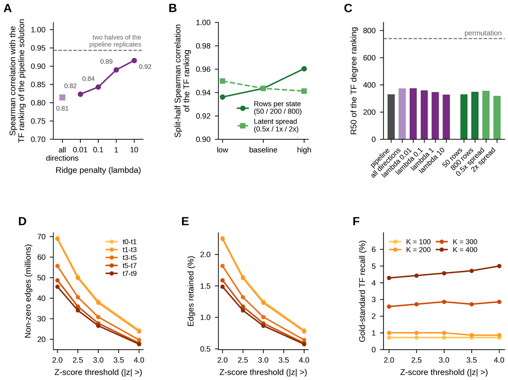

```python
figures.figure_lima_sensitivity()   # Figure S15, drawn from the tables above
display(Image(os.path.join(R, 'figures', 'figS_lima_sensitivity.png'), width=900))
```